# SIT 112 - Data Science Concepts

# Data Science Project

Lecturer: Dr. Uthayasanker Thayasivam | rtuthaya@cse.mrt.ac.lk

### Due: 12.00am, 28th Feb 2020

### Instructions

This notebook has been prepared for you to complete the Data Science Project. Some sections have been pre-filled to help you get started. **The total mark for this project is 150**.

There are two parts in this notebook that require you to complete:

- **Part 1**: *Linear Regression* (**100 marks**)
- **Part 2**: *Classification* (**50 marks**)

Each part includes three main components:

- **A:** Load a dataset from sklearn and examine it.
- **B:** Build a training model and make predictions.
- **C:** Report the results and visualize the data.

Before you start, read the entire notebook carefully to understand what you need to do. You should also refer to the main instructions in *Project_instructions.pdf* to know what else you need to complete for this project.

For each cell marked with **# YOU ARE REQUIRED TO INSERT YOUR CODES IN THIS CELL**, there will be places where you **must** supply your own codes when instructed.

In the end, you must execute the entire notebook and submit two files:

1. The source of your solution notebook: **[YourID]_project_solution.ipynb**
2. And an exported version of your output: **[YourID]_project_output.html**

As you go through this notebook:

- markdown cells marked with **Note** mean description sections.
- markdown cells marked with **Instructions** mean the instructions given to you to complete the sections.

Please proceed with the instructions for each part below to complete your programming tasks.

**Note**: The following packages will be required for this assignment. If you need to import more packages, you might append them to the end of the following cell.

```python
'''
Import packages needed for processing
'''
import numpy as np
import pandas as pd
from sklearn import datasets
import sklearn.metrics as metrics

from sklearn import linear_model
from sklearn import naive_bayes
from sklearn.manifold import TSNE
import matplotlib.pyplot as plt


%matplotlib inline

'''
If you need add any additional packages, then add them below this line
'''
from sklearn.metrics import mean_absolute_error
from sklearn.metrics import mean_squared_error
from sklearn.naive_bayes import MultinomialNB
from sklearn.metrics import accuracy_score
from sklearn.metrics import precision_score
from sklearn.metrics import recall_score
from sklearn.metrics import f1_score
```

# Part 1: Linear Regression

In this part, you will be required to work on Linear Regression for the **life-expectancy** dataset from sklearn. More about the dataset can be found in Project_Instruction.pdf

## Part 1A: Load and examine the life-expectancy dataset

**Instruction 1.1.** Write your code to load the **life-expectancy** dataset to pandas Dataframe from life_expectancy.csv provided

[**Total mark: 5**]

```python
# YOU ARE REQUIRED TO INSERT YOUR CODES IN THIS CELL
data = pd.read_csv('life_expectancy.csv')
```

**Instruction 1.2.** View first few rows of the loaded DataFrame

[**Total mark: 2**]

```python
# YOU ARE REQUIRED TO INSERT YOUR CODES IN THIS CELL
data.head()
```

|  | Country | Year | Status | Life expectancy | Adult Mortality | infant deaths | Alcohol | percentage expenditure | Hepatitis B | Measles | ... | Polio | Total expenditure | Diphtheria | HIV/AIDS | GDP | Population | thinness 1-19 years | thinness 5-9 years | Income composition of resources | Schooling |
| --- | --- | --- | --- | --- | --- | --- | --- | --- | --- | --- | --- | --- | --- | --- | --- | --- | --- | --- | --- | --- | --- |
| 0 | Afghanistan | 2015 | Developing | 65.0 | 263.0 | 62 | 0.01 | 71.279624 | 65.0 | 1154 | ... | 6.0 | 8.16 | 65.0 | 0.1 | 584.259210 | 33736494.0 | 17.2 | 17.3 | 0.479 | 10.1 |
| 1 | Afghanistan | 2014 | Developing | 59.9 | 271.0 | 64 | 0.01 | 73.523582 | 62.0 | 492 | ... | 58.0 | 8.18 | 62.0 | 0.1 | 612.696514 | 327582.0 | 17.5 | 17.5 | 0.476 | 10.0 |
| 2 | Afghanistan | 2013 | Developing | 59.9 | 268.0 | 66 | 0.01 | 73.219243 | 64.0 | 430 | ... | 62.0 | 8.13 | 64.0 | 0.1 | 631.744976 | 31731688.0 | 17.7 | 17.7 | 0.470 | 9.9 |
| 3 | Afghanistan | 2012 | Developing | 59.5 | 272.0 | 69 | 0.01 | 78.184215 | 67.0 | 2787 | ... | 67.0 | 8.52 | 67.0 | 0.1 | 669.959000 | 3696958.0 | 17.9 | 18.0 | 0.463 | 9.8 |
| 4 | Afghanistan | 2011 | Developing | 59.2 | 275.0 | 71 | 0.01 | 7.097109 | 68.0 | 3013 | ... | 68.0 | 7.87 | 68.0 | 0.1 | 63.537231 | 2978599.0 | 18.2 | 18.2 | 0.454 | 9.5 |

5 rows × 22 columns

**Instruction 1.3.** View information related to loaded DataFrame

[**Total mark: 3**]

```python
# YOU ARE REQUIRED TO INSERT YOUR CODES IN THIS CELL
data.info()
```

```
<class 'pandas.core.frame.DataFrame'>
RangeIndex: 2938 entries, 0 to 2937
Data columns (total 22 columns):
 #   Column                           Non-Null Count  Dtype
---  ------                           --------------  -----
 0   Country                          2938 non-null   object
 1   Year                             2938 non-null   int64
 2   Status                           2938 non-null   object
 3   Life expectancy                  2928 non-null   float64
 4   Adult Mortality                  2928 non-null   float64
 5   infant deaths                    2938 non-null   int64
 6   Alcohol                          2744 non-null   float64
 7   percentage expenditure           2938 non-null   float64
 8   Hepatitis B                      2385 non-null   float64
 9   Measles                          2938 non-null   int64
 10   BMI                             2904 non-null   float64
 11  under-five deaths                2938 non-null   int64
 12  Polio                            2919 non-null   float64
 13  Total expenditure                2712 non-null   float64
 14  Diphtheria                       2919 non-null   float64
 15   HIV/AIDS                        2938 non-null   float64
 16  GDP                              2490 non-null   float64
 17  Population                       2286 non-null   float64
 18   thinness  1-19 years            2904 non-null   float64
 19   thinness 5-9 years              2904 non-null   float64
 20  Income composition of resources  2771 non-null   float64
 21  Schooling                        2775 non-null   float64
dtypes: float64(16), int64(4), object(2)
memory usage: 505.1+ KB
```

**Instruction 1.4.** Convert categorical variable 'Status' in the Dataframe with Label Encoding.

Note: Dataframe after this operation should contain same number of columns with same column names.

[**Total mark: 10**]

```python
# YOU ARE REQUIRED TO INSERT YOUR CODES IN THIS CELL
data['Status'] = data['Status'].astype('category')
data['Status_Cat'] = data['Status'].cat.codes
print(data['Status_Cat'])
```

```
0       1
1       1
2       1
3       1
4       1
       ..
2933    1
2934    1
2935    1
2936    1
2937    1
Name: Status_Cat, Length: 2938, dtype: int8
```

```python
print(data[' BMI '])
```

```
0       19.1
1       18.6
2       18.1
3       17.6
4       17.2
        ...
2933    27.1
2934    26.7
2935    26.3
2936    25.9
2937    25.5
Name:  BMI , Length: 2938, dtype: float64
```

**Instruction 1.5.** Evaluate Correlations and Covariances of independent variables with respect to tatget variable, Life Expectancy.

[**Total mark: 15**]

```python
# YOU ARE REQUIRED TO INSERT YOUR CODES IN THIS CELL
HIV = data[' HIV/AIDS']
life_expectancy = data['Life expectancy ']
covariance = np.cov(HIV, life_expectancy)[0,0]
pearson_r = np.cov(HIV, life_expectancy)[0,0] / (HIV.std() * life_expectancy.std())
print(f"covariance:{covariance}")
print(f"Pearson Correlation: {pearson_r}")
```

```
covariance:25.783895744141788
Pearson Correlation: 0.5331641308090669
```

**Instruction 1.6.** Visulaize variation of ndependent variables with respect to tatget variable, Life Expectancy.

[**Total mark: 15**]

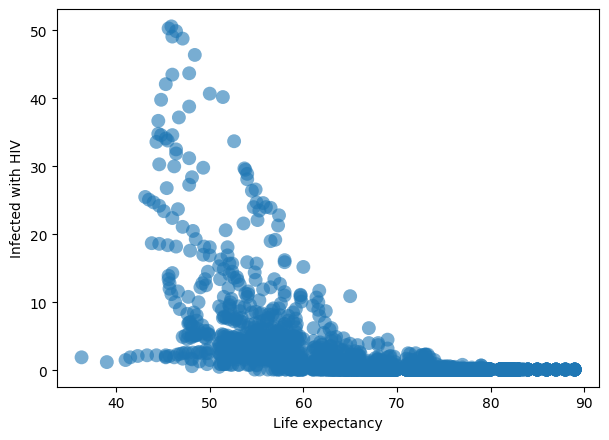

```python
# YOU ARE REQUIRED TO INSERT YOUR CODES IN THIS CELL
fig, ax = plt.subplots(figsize=(7, 5), dpi=100)
ax.scatter(life_expectancy,HIV, alpha=0.6, edgecolor='none', s=100)
ax.set_xlabel('Life expectancy')
ax.set_ylabel('Infected with HIV');
```

## Part 1B. Linear Regression

You are required to apply Linear Regression to train and make predictions on the **life-expectancy*** dataset.

**Note:** To perform a supervised learning task, we need to train the model on a training set of the input data and the correct labels, and predict the trained model on **unseen** data. Then, we use the correct labels of the **unseen** data to evaluate the performance of the model. The **unseen** dataset is called the **test set**.

**Instruction 1.7.** First you need to split the **life-expectancy** dataset (loaded Dataframe) into a training set and a test set. We will use 70% samples for training and 30% for testing. Print the number of samples in each set.

[**Total marks: 10**]

```python
data.describe()
```

|  | Year | Life expectancy | Adult Mortality | infant deaths | Alcohol | percentage expenditure | Hepatitis B | Measles | BMI | under-five deaths | ... | Total expenditure | Diphtheria | HIV/AIDS | GDP | Population | thinness 1-19 years | thinness 5-9 years | Income composition of resources | Schooling | Status_Cat |
| --- | --- | --- | --- | --- | --- | --- | --- | --- | --- | --- | --- | --- | --- | --- | --- | --- | --- | --- | --- | --- | --- |
| count | 2938.000000 | 2928.000000 | 2928.000000 | 2938.000000 | 2744.000000 | 2938.000000 | 2385.000000 | 2938.000000 | 2904.000000 | 2938.000000 | ... | 2712.00000 | 2919.000000 | 2938.000000 | 2490.000000 | 2.286000e+03 | 2904.000000 | 2904.000000 | 2771.000000 | 2775.000000 | 2938.000000 |
| mean | 2007.518720 | 69.224932 | 164.796448 | 30.303948 | 4.602861 | 738.251295 | 80.940461 | 2419.592240 | 38.321247 | 42.035739 | ... | 5.93819 | 82.324084 | 1.742103 | 7483.158469 | 1.275338e+07 | 4.839704 | 4.870317 | 0.627551 | 11.992793 | 0.825732 |
| std | 4.613841 | 9.523867 | 124.292079 | 117.926501 | 4.052413 | 1987.914858 | 25.070016 | 11467.272489 | 20.044034 | 160.445548 | ... | 2.49832 | 23.716912 | 5.077785 | 14270.169342 | 6.101210e+07 | 4.420195 | 4.508882 | 0.210904 | 3.358920 | 0.379405 |
| min | 2000.000000 | 36.300000 | 1.000000 | 0.000000 | 0.010000 | 0.000000 | 1.000000 | 0.000000 | 1.000000 | 0.000000 | ... | 0.37000 | 2.000000 | 0.100000 | 1.681350 | 3.400000e+01 | 0.100000 | 0.100000 | 0.000000 | 0.000000 | 0.000000 |
| 25% | 2004.000000 | 63.100000 | 74.000000 | 0.000000 | 0.877500 | 4.685343 | 77.000000 | 0.000000 | 19.300000 | 0.000000 | ... | 4.26000 | 78.000000 | 0.100000 | 463.935626 | 1.957932e+05 | 1.600000 | 1.500000 | 0.493000 | 10.100000 | 1.000000 |
| 50% | 2008.000000 | 72.100000 | 144.000000 | 3.000000 | 3.755000 | 64.912906 | 92.000000 | 17.000000 | 43.500000 | 4.000000 | ... | 5.75500 | 93.000000 | 0.100000 | 1766.947595 | 1.386542e+06 | 3.300000 | 3.300000 | 0.677000 | 12.300000 | 1.000000 |
| 75% | 2012.000000 | 75.700000 | 228.000000 | 22.000000 | 7.702500 | 441.534144 | 97.000000 | 360.250000 | 56.200000 | 28.000000 | ... | 7.49250 | 97.000000 | 0.800000 | 5910.806335 | 7.420359e+06 | 7.200000 | 7.200000 | 0.779000 | 14.300000 | 1.000000 |
| max | 2015.000000 | 89.000000 | 723.000000 | 1800.000000 | 17.870000 | 19479.911610 | 99.000000 | 212183.000000 | 87.300000 | 2500.000000 | ... | 17.60000 | 99.000000 | 50.600000 | 119172.741800 | 1.293859e+09 | 27.700000 | 28.600000 | 0.948000 | 20.700000 | 1.000000 |

8 rows × 21 columns

```python
split = 0.7
split_idx = int(np.round(split * len(data)))
split_idx
```

```
2057
```

```python
# YOU ARE REQUIRED TO INSERT YOUR CODES IN THIS CELL

train_data = data[0:2057]
test_data = data[2057:2938]

print(f"Number of samples in train data set: {len(train_data)}")
print(f"Number of samples in test data set: {len(test_data)}")
```

```
Number of samples in train data set: 2057
Number of samples in test data set: 881
```

**Instruction 1.8.** Choosing a suitable variable from previous statistcal analysis, create a Linear Regression model called `lr`.

[**Total marks: 10**]

```python
np.isnan(train_data['Life expectancy '])
np.where(np.isnan(train_data['Life expectancy ']))
X_train = np.nan_to_num(train_data['Life expectancy '])

np.isnan(train_data[' HIV/AIDS'])
np.where(np.isnan(train_data[' HIV/AIDS']))
Y_train = np.nan_to_num(train_data[' HIV/AIDS'])

np.isnan(test_data['Life expectancy '])
np.where(np.isnan(test_data['Life expectancy ']))
X_test = np.nan_to_num(test_data['Life expectancy '])

np.isnan(test_data[' HIV/AIDS'])
np.where(np.isnan(test_data[' HIV/AIDS']))
Y_test = np.nan_to_num(test_data[' HIV/AIDS'])
```

```python
# YOU ARE REQUIRED TO INSERT YOUR CODES IN THIS CELL
train_X = X_train
train_X = np.c_[train_X]
train_Y = Y_train.tolist()

test_X = X_test
test_X = np.c_[test_X]
test_Y = Y_test.tolist()
lr = linear_model.LinearRegression()# INSERT YOUR CODE HERE
```

**Instruction 1.9.** Fit the training data to the `lr` model.

[**Total marks: 5**]

```python
# YOU ARE REQUIRED TO INSERT YOUR CODES IN THIS CELL

lr.fit(train_X, train_Y)# INSERT YOUR CODE HERE
```

```
LinearRegression(copy_X=True, fit_intercept=True, n_jobs=None, normalize=False)
```

**Instruction 1.10** Predict the output of the test set.

[**Total marks: 5**]

```python
Y_pred = lr.predict(test_X)
# INSERT YOUR CODE HERE
```

## Part 1C. Results and Visualization

**Note:** To evaluate the performance of a Linear Regression model, two commonly used measures are **mean absolute error** and **root mean squared error**.

**mean absolute error** is defined by:

$$mean\_absolute\_error(Y_{test}, Y_{pred}) = \frac{1}{n_{samples}}\sum_{i=1}^{n_{samples}}|y_{test}^i - y_{pred}^i|$$

**root mean squared error** is defined by:

$$root\_mean\_squared\_error(Y_{test}, Y_{pred}) = \sqrt{\frac{1}{n_{samples}}\sum_{i=1}^{n_{samples}}(y_{test}^i - y_{pred}^i)^2}$$

**Instruction 1.11.** Compute **mean absolute error** and **root mean squared error** between the correct labels and the predictions of the test set and print these two values.

[**Total marks: 8**]

**Hint:** You might need to use [Regression metrics](http://scikit-learn.org/stable/modules/model_evaluation.html#regression-metrics) from sklearn.

```python
# YOU ARE REQUIRED TO INSERT YOUR CODES IN THIS CELL

# Compute the mean absolute error between Y_test and Y_pred
# Then, print the value
# INSERT YOUR CODE HERE
Y_absolute = mean_absolute_error(Y_test, Y_pred)
print(f"Mean absolute error: {Y_absolute}")

# Compute the root mean squared error between Y_test and Y_pred
# Then, print the value
# INSERT YOUR CODE HERE
Y_mean = mean_squared_error(Y_test, Y_pred)
print(f"root Mean squared error: {np.sqrt(Y_mean)}", )
```

```
Mean absolute error: 2.4100384942218422
root Mean squared error: 6.0974906692398285
```

**Note:** Visualisation is an important task. We want to see if two similar samples are predicted with two close labels. To evaluate how similar two samples are, we can compute their Euclidean distance and to evaluate how close the two labels are, we just need to compute their absolute difference.

The function below returns a Euclidean distance matrix whose element (i, j) stores the Euclidean distance between X[i] and X[j]. **You will need this function for a subsequent task.**

```python
def compute_euclidean_distance_matrix(X):
    n_samples = X.shape[0]

    # initialise the distance matrix and set all value to 0
    euclidean_distance_matrix = np.zeros([n_samples, n_samples], dtype=float)

    # compute the Euclidean distance matrix
    for i in range(n_samples):
        for j in range(n_samples):
            euclidean_distance_matrix[i, j] = np.sqrt(np.sum((X[i] - X[j]) ** 2))

    return euclidean_distance_matrix
```

**Instruction 1.12**. The following code segment is designed to visualise the Euclidean distances of the samples and the absolute differences of their predicted labels.

**Your tasks are:**

1. Construct a function that returns a matrix of absolute differences of the prediction **Y_pred** whose element (i, j) stores the absolute difference between Y_pred[i] and Y_pred[j]. (4 marks)
2. Compute the absolute difference matrix for **Y_pred** and visualise the matrix. (4 marks)
3. Compute the Euclidean distance matrix for **X_test** using compute_euclidean_distance_matrix() and visualise the matrix. (4 marks)

[**Total mark: 12**]

```python
# YOU ARE REQUIRED TO INSERT YOUR CODES IN THIS CELL
'''
1. Construct a function that returns a matrix of absolute difference of
    the prediction **Y_pred** whose element (i, j) stores
    the absolute difference between Y_pred[i] and Y_pred[j].
'''
def compute_abs_difference_matrix(Y):
    # compute the absolute difference matrix
    # and remember to return the matrix
    # INSERT YOUR CODE HERE
    Y_samples = Y.shape[0]
    absolute_diff = np.zeros((Y_samples, Y_samples))
    for i in range(Y_samples):
        for j in range(Y_samples):
            absolute_diff[i][j] = abs(i - j)
    return absolute_diff
```

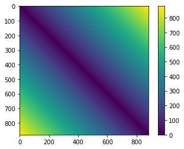

```python
# YOU ARE REQUIRED TO INSERT YOUR CODES IN THIS CELL
'''
2. Compute the absolute difference matrix for Y_pred and visualise the matrix
Hint: You might want to use imshow function.
'''

# compute the absolute difference matrix
abs_difference_matrix = compute_abs_difference_matrix(Y_pred)# INSERT YOUR CODE HERE

# visualise the matrix
# INSERT YOUR CODE HERE
plt.imshow(abs_difference_matrix)
plt.colorbar()
plt.show()
```

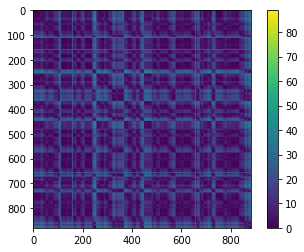

```python
# YOU ARE REQUIRED TO INSERT YOUR CODES IN THIS CELL
'''
3. Compute the Euclidean distance matrix for X_test and visualise the matrix.
Hint: You might want to use imshow function
'''

# compute the Euclidean distance matrix
X_test = test_X
Euclidean_distance_matrix = compute_euclidean_distance_matrix(X_test)# INSERT YOUR CODE HERE

# visualise the matrix
# INSERT YOUR CODE HERE
plt.imshow(Euclidean_distance_matrix)
plt.colorbar()
plt.show()
```

# Part 2: Classification

In this part, you will be required to apply Naive Bayes algorithm for the classification task on the **breast cancer** dataset from sklearn. More about the dataset can be found [here](http://scikit-learn.org/stable/modules/generated/sklearn.datasets.load_breast_cancer.html#sklearn.datasets.load_breast_cancer).

Here, we apply Multinomial Naive Bayes for discrete features. We can construct a Multinomial Naive Bayes model by calling **naive_bayes.MultinomialNB()** from sklearn package. More about the model can be found [here](http://scikit-learn.org/stable/modules/generated/sklearn.naive_bayes.MultinomialNB.html#sklearn.naive_bayes.MultinomialNB)

## Part 2A: Load and examine the dataset

**Instruction 2.1.** Write your code to load the **breast cancer** dataset from sklearn and assign it to a variable called `cancer`.

[**Total mark: 3**]

```python
# YOU ARE REQUIRED TO INSERT YOUR CODES IN THIS CELL
'''
1. Write your code to load the dataset from sklearn and assign it to a variable called `cancer`.
'''
cancer = datasets.load_breast_cancer()# INSERT YOUR CODE HERE

print(cancer.keys())
```

```
dict_keys(['data', 'target', 'target_names', 'DESCR', 'feature_names', 'filename'])
```

**Note:** The cell code below assigns the data to variable `X` and the labels to variable `Y`. Run the cell and use `X` and `Y` for later tasks.

```python
X = cancer['data']
Y = cancer['target']
```

**Instruction 2.2.** Now you need to examine the size of data. Write your code to find and print out the number of **samples** and the number of **features** in the dataset.

[**Total mark: 2**]

```python
# YOU ARE REQUIRED TO INSERT YOUR CODES IN THIS CELL
'''
2. Write your code to find and print out the number of **samples**
    and the number of **features** in the dataset.
    Using variable X.
'''
n_samples, n_features = X.shape
print('The number of samples:')
# INSERT YOUR CODE HERE
print(n_samples)
print('The number of features:')
# INSERT YOUR CODE HERE
print(n_features)
```

```
The number of samples:
569
The number of features:
30
```

**Instruction 2.3.** The following code segment is designed to do some statistics on the labels to get a brief understanding about the prediction task. This is a classication task, it is important to know the number of categories (or number of classes) in the dataset and their frequencies.

**Your tasks are:**

1. Write your code to compute and print the number of classes in the dataset. (2 marks)
2. Write your code to compute and print the number of occurrences of each class. (3 marks)

[**Total marks: 5**]

```python
# YOU ARE REQUIRED TO INSERT YOUR CODES IN THIS CELL
'''
1. Write your code to compute and print the number of classes in the dataset.
    Using variable Y.
'''

# compute and print the number of classes.
# INSERT YOUR CODE HERE
n_classes = len(np.unique(Y))
print(f"Number of classes in the dataset: {n_classes}")
```

```
Number of classes in the dataset: 2
```

```python
# YOU ARE REQUIRED TO INSERT YOUR CODES IN THIS CELL
'''
2. Write your code to compute and print the number of occurrences of each class.
'''

# compute and print the number of occurrences of each class
# INSERT YOUR CODE HERE
n_occur_class = np.bincount(Y)
print(f"Number of occurrences of each class: {n_occur_class[0]} and {n_occur_class[1]}")
```

```
Number of occurrences of each class: 212 and 357
```

## Part 2B. Classification with Naive Bayes

You are required to apply Naive Bayes to train and make predictions on the **breast cancer** dataset.

Multinomial Naive Bayes classifier is used for discrete data. The features of the breast cancer dataset are however real values. The function below discretise the features in to 0 (low), 1 (middle) and 2 (high). **Run the cell below.**

```python
def discretise(X):
    # for each feature, values smaller than 33% percentile are set by 0 (low),
    # from 33% to 67% percentile are set by 1 (middle) and other are set by 2 (high).

    n_feats = X.shape[-1]
    X_discrete = np.zeros(X.shape)

    for i in range(n_feats):
        # compute val1 and val2 as the percentile of 33% and 67%, respectively of the column i
        val1, val2 = np.percentile(X[:, i], 33), np.percentile(X[:, i], 67)

        # increase all discrete values by 1 for all values in X that larger than val1
        ids = np.where(X[:, i] > val1)[0]
        X_discrete[ids, i] += 1

        # increase all discrete values by 1 for all values in X that larger than val2
        ids = np.where(X[:, i] > val2)[0]
        X_discrete[ids, i] += 1

    return X_discrete
```

Then we call the discretise function for the feature X. **Run the cell below and your data are ready for classification.**

```python
X = discretise(X)
```

**Instruction 2.4.** Similar to **Part 1**, you need to split the dataset into a training set and a test set. We will use 70% samples for training and 30% for testing. Print the number of samples in each set.

[**Total marks: 5**]

```python
# YOU ARE REQUIRED TO INSERT YOUR CODES IN THIS CELL

# first, compute the number of samples in the training set:
n_train = int(len(Y) * 0.7)

# The training set is the first n_train samples in the dataset
X_train = np.nan_to_num(X[:n_train])
X_train = np.c_[X_train]# INSERT YOUR CODE HERE
Y_train = np.nan_to_num(Y[:n_train])
Y_train = Y_train.tolist()#INSERT YOUR CODE HERE

# The test set is the remaining samples in the dataset
X_test = np.nan_to_num(X[n_train:len(Y)])
X_test = np.c_[X_test]# INSERT YOUR CODE HERE
Y_test = np.nan_to_num(Y[n_train:len(Y)])
Y_test = Y_test.tolist()# INSERT YOUR CODE HERE

# Print the number of samples in the training set
print('The number of samples in the training set:')
# INSERT YOUR CODE HERE
print(n_train)
# Print the number of samples in the test set
print('The number of samples in the test set:')
# INSERT YOUR CODE HERE
print(len(Y) - n_train)
```

```
The number of samples in the training set:
398
The number of samples in the test set:
171
```

```python
#This is my own added code to check the output
print(n_train)
print(len(Y))
print(Y[:n_train])
```

```
398
569
[0 0 0 0 0 0 0 0 0 0 0 0 0 0 0 0 0 0 0 1 1 1 0 0 0 0 0 0 0 0 0 0 0 0 0 0 0
 1 0 0 0 0 0 0 0 0 1 0 1 1 1 1 1 0 0 1 0 0 1 1 1 1 0 1 0 0 1 1 1 1 0 1 0 0
 1 0 1 0 0 1 1 1 0 0 1 0 0 0 1 1 1 0 1 1 0 0 1 1 1 0 0 1 1 1 1 0 1 1 0 1 1
 1 1 1 1 1 1 0 0 0 1 0 0 1 1 1 0 0 1 0 1 0 0 1 0 0 1 1 0 1 1 0 1 1 1 1 0 1
 1 1 1 1 1 1 1 1 0 1 1 1 1 0 0 1 0 1 1 0 0 1 1 0 0 1 1 1 1 0 1 1 0 0 0 1 0
 1 0 1 1 1 0 1 1 0 0 1 0 0 0 0 1 0 0 0 1 0 1 0 1 1 0 1 0 0 0 0 1 1 0 0 1 1
 1 0 1 1 1 1 1 0 0 1 1 0 1 1 0 0 1 0 1 1 1 1 0 1 1 1 1 1 0 1 0 0 0 0 0 0 0
 0 0 0 0 0 0 0 1 1 1 1 1 1 0 1 0 1 1 0 1 1 0 1 0 0 1 1 1 1 1 1 1 1 1 1 1 1
 1 0 1 1 0 1 0 1 1 1 1 1 1 1 1 1 1 1 1 1 1 0 1 1 1 0 1 0 1 1 1 1 0 0 0 1 1
 1 1 0 1 0 1 0 1 1 1 0 1 1 1 1 1 1 1 0 0 0 1 1 1 1 1 1 1 1 1 1 1 0 0 1 0 0
 0 1 0 0 1 1 1 1 1 0 1 1 1 1 1 0 1 1 1 0 1 1 0 0 1 1 1 1]
```

**Instruction 2.5.** Create a Multinomial Naive Bayes model called `mnb`.

[**Total marks: 5**]

```python
# YOU ARE REQUIRED TO INSERT YOUR CODES IN THIS CELL

mnb = MultinomialNB()# INSERT YOUR CODE HERE
```

**Instruction 2.6.** Fit the training data to the `mnb` model.

[**Total marks: 5**]

```python
# YOU ARE REQUIRED TO INSERT YOUR CODES IN THIS CELL

mnb.fit(X_train,Y_train)# INSERT YOUR CODE HERE
```

```
MultinomialNB(alpha=1.0, class_prior=None, fit_prior=True)
```

**Instruction 2.7** Predict the output of the test set.

[**Total marks: 5**]

```python
Y_pred = mnb.predict(X_test)# INSERT YOUR CODE HERE
print(Y_pred)
```

```
[1 1 0 0 1 0 1 1 0 1 0 1 1 1 1 0 0 1 1 0 1 1 1 1 1 0 1 1 1 1 1 0 0 1 0 0 0
 0 1 1 0 0 1 0 0 1 0 1 0 0 0 0 1 0 1 1 0 0 1 0 0 1 0 0 0 1 0 0 0 1 0 1 1 1
 0 1 1 0 0 0 1 0 1 0 1 0 0 1 0 0 1 0 0 0 0 1 1 0 1 0 0 0 0 1 1 0 1 1 1 1 0
 0 1 0 0 0 0 1 0 0 0 1 1 0 1 1 1 1 0 0 1 1 1 1 0 0 1 0 0 1 1 1 1 0 0 0 1 0
 1 1 1 1 1 1 1 1 1 1 1 1 0 1 1 1 0 0 0 0 0 0 1]
```

## Part 1C. Results and Visualization

**Note:** To evaluate the performance of a classification task, commonly used measures are **accuracy**, **precision**, **recall** and **f1-score**.

**Instruction 2.8.** Compute the **accuracy**, **precision**, **recall** and **f1-score** of the predictions on the test set and print these values.

[**Total marks: 12**]

**Hint:** You might need to see [Classification metrics](http://scikit-learn.org/stable/modules/model_evaluation.html#classification-metrics) from sklearn.

```python
# YOU ARE REQUIRED TO INSERT YOUR CODES IN THIS CELL

# Compute and print the accuracy of predictions on the test set
# INSERT YOUR CODE HERE
accuracy = accuracy_score(Y_test, Y_pred)
print("Accuracy of predictions: ", accuracy)
# Compute and print the precision of predictions on the test set
# INSERT YOUR CODE HERE
precision = precision_score(Y_test, Y_pred)
print("precision of predictions: ", precision)

# Compute and print the recall of predictions on the test set
# INSERT YOUR CODE HERE
recall = recall_score(Y_test, Y_pred)
print("recall of predictions: ", recall)

# Compute and print the f1-score of predictions on the test set
# INSERT YOUR CODE HERE
f1 = f1_score(Y_test, Y_pred)
print("f1-score of predictions: ", f1)
```

```
Accuracy of predictions:  0.7309941520467836
precision of predictions:  0.9886363636363636
recall of predictions:  0.6590909090909091
f1-score of predictions:  0.790909090909091
```

**Note:** We have evaluated the performance of the classification task by different measures. Now, we want to visualise the data as well as the predicted labels. [t-SNE](http://scikit-learn.org/stable/modules/generated/sklearn.manifold.TSNE.html) is a tool to convert high-dimensional data into low-dimensional ones. To visualise the data, we can use t-SNE to reduce the data dimension to 2D.

The following function `reduce_to_2D` takes the matrix X of size (n_samples, n_features) and returns a matrix of size (n_samples, 2), which is a dimension-reduced version of X. **You will need this function for a subsequent task**.

```python
def reduce_to_2D(X):
    tsne = TSNE(n_components=2, random_state=1)
    new_X = tsne.fit_transform(X)
    return new_X
```

**Instruction 2.9**. Visualisation.

**Your tasks are:**

1. Create a variable named `X_test_2D` that is the dimension-reduced version of X_test using function `reduce_to_2D`. (4 marks)
2. Visualise `X_test_2D` using scatter() with the colors being the corresponding predicted labels. (4 marks)

[**Total mark: 8**]

```python
# YOU ARE REQUIRED TO INSERT YOUR CODES IN THIS CELL
'''
1. Create a variable named `X_test_2D`
    that is the dimension-reduced version of X_test using function `reduce_to_2D`.
'''

# INSERT YOUR CODE HERE
X_test_2D = reduce_to_2D(X_test)
```

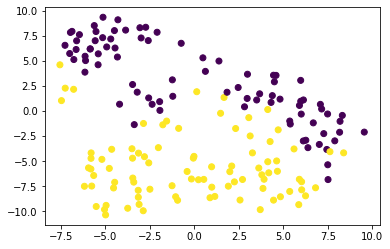

```python
# YOU ARE REQUIRED TO INSERT YOUR CODES IN THIS CELL
'''
2. Visualise `X_test_2D` by scatters with the colors being the corresponding predicted labels.
'''

# INSERT YOUR CODE HERE
x = X_test_2D[0:, 0]
y = X_test_2D[0:, 1]

plt.scatter(x, y, c=Y_pred)

plt.show()
```